# Diff-in-Diff Borusyak: Python Commit-Function AGC Outcomes by AST Sequence Token Band

# 1 Purpose

This notebook runs Borusyak imputation DiD models for one pre-specified, bounded AST sequence token band produced by run-py-6a. The wrapper passes one of the ten bands from 50-59 through 140-149 and renders this notebook independently for the full zero-inclusive panel and the conditional ratio-positive panel.

The notebook estimates the Heterogeneity RQ. The Primary RQ uses the separate minimum-threshold specification `ast_sequence_token_count >= 50` with no upper bound and is not estimated here.

The notebook deliberately separates:

1. Full repository-month occurrence and count outcomes.
2. The conditional AGC event ratio among positive-event repository-months.
3. Paper NCLOC and Python-snapshot NCLOC specifications.
4. Full and parse-clean samples, selected through `PARSE_EXCLUSION_MODE`.
5. The ten bounded AST sequence token bands, verified against input metadata.

For each band, the canonical arithmetic is:

- `function_change_events = agc_function_change_events + hwc_function_change_events`
- `agc_function_change_event_ratio = agc_function_change_events / function_change_events`

The ratio remains missing when the denominator is zero. Count outcomes use `log1p()` transformations. Repository-month activity outcomes `log1p_commits` and `log1p_lines_added` are retained and validated as common reference outcomes, but are not re-estimated separately in every band because they do not vary by AST sequence token band.

The two NCLOC variables are never included in the same first-stage formula. Lead/lag columns retained by run-py-5e are validation fields only; dynamic coefficients are requested from `didimputation::did_imputation()` using `horizon = -6:6` and `pretrends = -6:-2`.

Regression guards carried over from the validated run-py-5f notebook are retained. Additional band-specific guards verify the label and inclusive / exclusive bounds, bounded-band specification, AGC/HWC partition, log1p transformations, zero-denominator ratio handling, and ratio bounds.

# 2 Load Packages and Helper Functions

```r
library(data.table)
library(dplyr)
```

```r
library(ggplot2)
library(didimputation)
if (!file.exists(helper_path)) {
  stop("Helper file not found: ", helper_path)
}

source(helper_path)
```

# 3 Utility Functions

```r
normalize_yyyymm <- function(x) {
  x <- as.character(x)
  x[x %in% c("", "NA", "NaN", "NULL", "None")] <- NA_character_
  x <- gsub("-", "", x)
  suppressWarnings(as.integer(x))
}

yyyymm_to_month_id <- function(x) {
  x <- as.integer(x)
  year <- x %/% 100L
  month <- x %% 100L
  out <- year * 12L + month
  out[is.na(x) | month < 1L | month > 12L] <- NA_integer_
  out
}

require_columns <- function(data, required, label) {
  missing <- setdiff(required, names(data))
  if (length(missing) > 0) {
    stop(label, " missing required columns: ", paste(missing, collapse = ", "))
  }
}

count_nonmissing <- function(data, column_name) {
  if (!(column_name %in% names(data))) {
    return(NA_integer_)
  }
  sum(!is.na(data[[column_name]]))
}

write_error_table <- function(errors, stage, output_path, metadata) {
  if (length(errors) == 0) {
    error_df <- data.frame(
      stage = character(),
      outcome = character(),
      error = character(),
      stringsAsFactors = FALSE
    )
  } else {
    error_df <- data.frame(
      stage = stage,
      outcome = names(errors),
      error = unlist(errors),
      row.names = NULL,
      stringsAsFactors = FALSE
    )
  }

  for (metadata_name in names(metadata)) {
    error_df[[metadata_name]] <- rep(
      as.character(metadata[[metadata_name]]),
      nrow(error_df)
    )
  }
  fwrite(error_df, output_path)
}

add_run_metadata <- function(data, metadata) {
  for (metadata_name in names(metadata)) {
    data[[metadata_name]] <- metadata[[metadata_name]]
  }
  data
}
```

# 4 Load and Validate Input Panel

```r
cat("Project root:", project_root, "\n")
```

```
## Project root: /home/user1-system12/project-workspace/ai_code_complexity_study_python/ai-code-complexity-study
```

```r
cat("Panel path:", panel_path, "\n")
```

```
## Panel path: /home/user1-system12/project-workspace/ai_code_complexity_study_python/ai-code-complexity-study/repo_python/run-py-6a/strict/bands/90-99/panel_event_monthly_agc_commit_function_ast_90_99_ratio_positive.csv
```

```r
cat("Panel label:", panel_label, "\n")
```

```
## Panel label: strict_band_90_99_ratio_paper_ncloc_calendar_month_all
```

```r
cat("Output directory:", out_dir, "\n")
```

```
## Output directory: /home/user1-system12/project-workspace/ai_code_complexity_study_python/ai-code-complexity-study/repo_python/run-py-6b/strict/bands/90-99/ratio/paper_ncloc/calendar_month/all
```

```r
cat("NCLOC specification:", ncloc_spec, "\n")
```

```
## NCLOC specification: paper
```

```r
cat("Sample type:", sample_type, "\n")
```

```
## Sample type: ratio
```

```r
cat("Time mode:", time_mode, "\n")
```

```
## Time mode: calendar_month
```

```r
cat("Parse-exclusion mode:", parse_exclusion_mode, "\n")
```

```
## Parse-exclusion mode: all
```

```r
cat("AST sequence token band:", ast_sequence_token_band, "\n")
```

```
## AST sequence token band: 90-99
```

```r
cat("AST sequence token lower bound (inclusive):",
    ast_sequence_token_lower, "\n")
```

```
## AST sequence token lower bound (inclusive): 90
```

```r
cat("AST sequence token upper bound (exclusive):",
    ast_sequence_token_upper_exclusive, "\n")
```

```
## AST sequence token upper bound (exclusive): 100
```

```r
if (!file.exists(panel_path)) {
  stop("Panel file not found: ", panel_path)
}

panel_raw <- fread(panel_path)

base_required <- c(
  "dataset_source",
  "repo_name",
  "time",
  "event",
  "time_to_event",
  "function_change_events",
  "agc_function_change_events",
  "hwc_function_change_events",
  "has_function_change_event",
  "zero_function_event_month",
  "agc_function_change_event_ratio",
  "log1p_function_change_events",
  "log1p_agc_function_change_events",
  "log1p_hwc_function_change_events",
  "commits",
  "lines_added",
  "log1p_commits",
  "log1p_lines_added",
  "ast_sequence_token_lower_bound_inclusive",
  "ast_sequence_token_upper_bound_exclusive",
  "ast_sequence_token_band",
  "ast_sequence_token_specification",
  "log1p_age",
  "log1p_contributors",
  "log1p_stars",
  "log1p_issues",
  "ncloc_paper",
  "ncloc_python_snapshot",
  "analysis_ready_paper_ncloc",
  "analysis_ready_python_snapshot_ncloc",
  "analysis_ready_ratio_paper_ncloc",
  "analysis_ready_ratio_python_snapshot_ncloc",
  "has_parse_exclusion",
  "detection_complete",
  "treatment_group"
)
require_columns(panel_raw, base_required, "Input panel")

band_labels_in_input <- unique(as.character(panel_raw$ast_sequence_token_band))
band_lower_values_in_input <- unique(
  as.integer(panel_raw$ast_sequence_token_lower_bound_inclusive)
)
band_upper_values_in_input <- unique(
  as.integer(panel_raw$ast_sequence_token_upper_bound_exclusive)
)
band_specs_in_input <- unique(
  as.character(panel_raw$ast_sequence_token_specification)
)

band_label_mismatch_rows <- sum(
  as.character(panel_raw$ast_sequence_token_band) != ast_sequence_token_band |
    is.na(panel_raw$ast_sequence_token_band)
)
band_lower_mismatch_rows <- sum(
  as.integer(panel_raw$ast_sequence_token_lower_bound_inclusive) !=
    ast_sequence_token_lower |
    is.na(panel_raw$ast_sequence_token_lower_bound_inclusive)
)
band_upper_mismatch_rows <- sum(
  as.integer(panel_raw$ast_sequence_token_upper_bound_exclusive) !=
    ast_sequence_token_upper_exclusive |
    is.na(panel_raw$ast_sequence_token_upper_bound_exclusive)
)
band_specification_mismatch_rows <- sum(
  as.character(panel_raw$ast_sequence_token_specification) != "bounded_band" |
    is.na(panel_raw$ast_sequence_token_specification)
)

if (length(band_labels_in_input) != 1L || band_label_mismatch_rows > 0) {
  stop(
    "Input panel AST band label does not match the requested band. Values: ",
    paste(band_labels_in_input, collapse = ", ")
  )
}
if (length(band_lower_values_in_input) != 1L || band_lower_mismatch_rows > 0) {
  stop("Input panel AST lower bound does not match the requested lower bound.")
}
if (length(band_upper_values_in_input) != 1L || band_upper_mismatch_rows > 0) {
  stop("Input panel AST upper bound does not match the requested upper bound.")
}
if (length(band_specs_in_input) != 1L ||
    band_specification_mismatch_rows > 0) {
  stop("Input panel must use ast_sequence_token_specification=bounded_band.")
}

count_na_rows <- sum(
  is.na(panel_raw$function_change_events) |
    is.na(panel_raw$agc_function_change_events) |
    is.na(panel_raw$hwc_function_change_events)
)
count_negative_rows <- sum(
  panel_raw$function_change_events < 0 |
    panel_raw$agc_function_change_events < 0 |
    panel_raw$hwc_function_change_events < 0,
  na.rm = TRUE
)
log1p_count_missing_rows <- sum(
  is.na(panel_raw$log1p_function_change_events) |
    is.na(panel_raw$log1p_agc_function_change_events) |
    is.na(panel_raw$log1p_hwc_function_change_events)
)
activity_missing_rows <- sum(
  is.na(panel_raw$commits) | is.na(panel_raw$lines_added)
)
log1p_activity_missing_rows <- sum(
  is.na(panel_raw$log1p_commits) | is.na(panel_raw$log1p_lines_added)
)
function_event_partition_mismatch_rows <- sum(
  panel_raw$function_change_events !=
    panel_raw$agc_function_change_events +
    panel_raw$hwc_function_change_events,
  na.rm = TRUE
)
log1p_function_mismatch_rows <- sum(
  abs(
    panel_raw$log1p_function_change_events -
      log1p(panel_raw$function_change_events)
  ) > 1e-12,
  na.rm = TRUE
)
log1p_agc_mismatch_rows <- sum(
  abs(
    panel_raw$log1p_agc_function_change_events -
      log1p(panel_raw$agc_function_change_events)
  ) > 1e-12,
  na.rm = TRUE
)
log1p_hwc_mismatch_rows <- sum(
  abs(
    panel_raw$log1p_hwc_function_change_events -
      log1p(panel_raw$hwc_function_change_events)
  ) > 1e-12,
  na.rm = TRUE
)
activity_negative_rows <- sum(
  panel_raw$commits < 0 | panel_raw$lines_added < 0,
  na.rm = TRUE
)
log1p_commits_mismatch_rows <- sum(
  abs(panel_raw$log1p_commits - log1p(panel_raw$commits)) > 1e-12,
  na.rm = TRUE
)
log1p_lines_added_mismatch_rows <- sum(
  abs(panel_raw$log1p_lines_added - log1p(panel_raw$lines_added)) > 1e-12,
  na.rm = TRUE
)
positive_event_rows <- panel_raw$function_change_events > 0
zero_event_rows <- panel_raw$function_change_events == 0
positive_ratio_missing_rows <- sum(
  positive_event_rows & is.na(panel_raw$agc_function_change_event_ratio)
)
zero_ratio_nonmissing_rows <- sum(
  zero_event_rows & !is.na(panel_raw$agc_function_change_event_ratio)
)
ratio_formula_mismatch_rows <- sum(
  positive_event_rows &
    abs(
      panel_raw$agc_function_change_event_ratio -
        panel_raw$agc_function_change_events /
        panel_raw$function_change_events
    ) > 1e-12,
  na.rm = TRUE
)
ratio_out_of_bounds_input_rows <- sum(
  !is.na(panel_raw$agc_function_change_event_ratio) &
    !panel_raw$agc_function_change_event_ratio %between% c(0, 1),
  na.rm = TRUE
)

if (count_na_rows > 0 || count_negative_rows > 0 ||
    log1p_count_missing_rows > 0 || activity_missing_rows > 0 ||
    log1p_activity_missing_rows > 0 ||
    function_event_partition_mismatch_rows > 0 ||
    log1p_function_mismatch_rows > 0 || log1p_agc_mismatch_rows > 0 ||
    log1p_hwc_mismatch_rows > 0 || activity_negative_rows > 0 ||
    log1p_commits_mismatch_rows > 0 ||
    log1p_lines_added_mismatch_rows > 0 ||
    positive_ratio_missing_rows > 0 || zero_ratio_nonmissing_rows > 0 ||
    ratio_formula_mismatch_rows > 0 || ratio_out_of_bounds_input_rows > 0) {
  stop(
    "Band outcome contract violated. See the band-specific arithmetic, ",
    "log1p, activity, and ratio mismatch counters in the source."
  )
}

if (anyDuplicated(panel_raw[, .(dataset_source, repo_name, time)]) > 0) {
  stop("Input panel has duplicate dataset_source/repo_name/time keys.")
}

if (!all(panel_raw$dataset_source %in% c("control", "treatment"))) {
  stop("dataset_source contains unexpected values.")
}

# Regression guard 1 (run-py-5d bug history): static cohort membership must
# come from dataset_source, never from the dynamic is_treatment indicator.
# treatment_group is required to match dataset_source on every row.
treatment_group_mismatch_rows <- sum(
  as.character(panel_raw$treatment_group) !=
    as.character(panel_raw$dataset_source),
  na.rm = TRUE
) + sum(is.na(panel_raw$treatment_group))

if (treatment_group_mismatch_rows > 0) {
  stop(
    "treatment_group does not match dataset_source on ",
    treatment_group_mismatch_rows,
    " rows. Static membership must be derived from dataset_source."
  )
}

# Regression guard 2 (run-py-5d dtype history): detection_complete must be a
# clean all-true indicator. Accept boolean or normalized text/numeric forms,
# but reject any missing or false value.
detection_complete_true <- panel_raw$detection_complete %in%
  c(TRUE, 1L, 1.0, "True", "TRUE", "true", "1", "1.0")
detection_incomplete_rows <- sum(!detection_complete_true)

if (detection_incomplete_rows > 0) {
  stop(
    "detection_complete is not uniformly true: ",
    detection_incomplete_rows,
    " rows are missing, false, or malformed."
  )
}

# Regression guard 3: zero-event arithmetic from the run-py-5d complete
# table must hold exactly on the full input panel. NA values in these three
# columns are contract violations, not skippable rows.
event_core_na_rows <- sum(
  is.na(panel_raw$function_change_events) |
    is.na(panel_raw$has_function_change_event) |
    is.na(panel_raw$zero_function_event_month)
)
if (event_core_na_rows > 0) {
  stop(
    "Missing values in core event columns on ",
    event_core_na_rows,
    " rows; run-py-5e must deliver a zero-inclusive complete panel."
  )
}

occurrence_mismatch_rows <- sum(
  as.integer(panel_raw$has_function_change_event) !=
    as.integer(panel_raw$function_change_events > 0),
  na.rm = TRUE
)
zero_flag_mismatch_rows <- sum(
  as.integer(panel_raw$zero_function_event_month) !=
    (1L - as.integer(panel_raw$has_function_change_event)),
  na.rm = TRUE
)

if (occurrence_mismatch_rows > 0 || zero_flag_mismatch_rows > 0) {
  stop(
    "Zero-event arithmetic violated. Occurrence mismatches: ",
    occurrence_mismatch_rows,
    "; zero-flag mismatches: ",
    zero_flag_mismatch_rows
  )
}

cat("Loaded rows:", nrow(panel_raw), "\n")
```

```
## Loaded rows: 831
```

```r
cat("Loaded repositories:", uniqueN(panel_raw$repo_name), "\n")
```

```
## Loaded repositories: 169
```

```r
cat("Treatment rows (dataset_source):",
    sum(panel_raw$dataset_source == "treatment"), "\n")
```

```
## Treatment rows (dataset_source): 530
```

```r
cat("Control rows (dataset_source):",
    sum(panel_raw$dataset_source == "control"), "\n")
```

```
## Control rows (dataset_source): 301
```

```r
cat("Zero-event rows in input:",
    sum(panel_raw$zero_function_event_month == 1, na.rm = TRUE), "\n")
```

```
## Zero-event rows in input: 0
```

```r
# Regression guard 4: event-month presence must reproduce static cohort
# membership on the full 1,633-row input, before any readiness or cohort
# filtering removes rows. Treatment rows must carry a non-missing event
# month; control rows must carry a missing event.
panel_raw[, event_is_missing := is.na(event) | as.character(event) == ""]
full_input_event_membership_mismatch_rows <- panel_raw[
  ,
  sum((dataset_source == "treatment") == event_is_missing)
]
if (full_input_event_membership_mismatch_rows > 0) {
  stop(
    "Event-month presence disagrees with dataset_source on ",
    full_input_event_membership_mismatch_rows,
    " rows of the full 1,633-row input panel."
  )
}

# Regression guard 5: repository-level treatment consistency. A repository
# must map to exactly one dataset_source and, if treated, exactly one
# adoption month.
repo_source_counts <- panel_raw[, .(n_sources = uniqueN(dataset_source)),
                                  by = repo_name]
repo_source_violations <- sum(repo_source_counts$n_sources > 1)
if (repo_source_violations > 0) {
  stop(
    "Repository-level dataset_source is not unique for ",
    repo_source_violations,
    " repositories."
  )
}

repo_event_counts <- panel_raw[
  dataset_source == "treatment" & !event_is_missing,
  .(n_events = uniqueN(event)),
  by = repo_name
]
repo_event_violations <- sum(repo_event_counts$n_events > 1)
if (repo_event_violations > 0) {
  stop(
    "Repository-level adoption month is not unique for ",
    repo_event_violations,
    " treatment repositories."
  )
}
```

# 5 Select Outcomes, Covariates, and Explicit Analysis Sample

```r
if (sample_type == "full") {
  outcome_vars <- c(
    "has_function_change_event",
    "log1p_function_change_events",
    "log1p_agc_function_change_events",
    "log1p_hwc_function_change_events"
  )
  outcome_names <- c(
    "Any Function-Change Event",
    "Total Function-Change Events (log1p)",
    "AGC-Like Function-Change Events (log1p)",
    "HWC-Like Function-Change Events (log1p)"
  )
} else {
  outcome_vars <- c("agc_function_change_event_ratio")
  outcome_names <- c("AGC-Like Event Share | Positive-Event Month")
}

if (ncloc_spec == "paper") {
  ncloc_column <- "ncloc_paper"
  readiness_column <- if (sample_type == "full") {
    "analysis_ready_paper_ncloc"
  } else {
    "analysis_ready_ratio_paper_ncloc"
  }
} else {
  ncloc_column <- "ncloc_python_snapshot"
  readiness_column <- if (sample_type == "full") {
    "analysis_ready_python_snapshot_ncloc"
  } else {
    "analysis_ready_ratio_python_snapshot_ncloc"
  }
}

covariates <- c(
  "log1p_age",
  ncloc_column,
  "log1p_contributors",
  "log1p_stars",
  "log1p_issues"
)

require_columns(
  panel_raw,
  c(outcome_vars, covariates, readiness_column),
  "Configured model"
)

panel_data <- copy(panel_raw)
panel_data <- panel_data[get(readiness_column) == 1]
rows_after_readiness_filter <- nrow(panel_data)

if (parse_exclusion_mode == "parse_clean") {
  panel_data <- panel_data[has_parse_exclusion == 0]
}
rows_after_parse_filter <- nrow(panel_data)

if (sample_type == "ratio") {
  panel_data <- panel_data[
    function_change_events > 0 &
      !is.na(agc_function_change_event_ratio)
  ]
}
rows_after_ratio_filter <- nrow(panel_data)

if (nrow(panel_data) == 0) {
  stop("No rows remain after the explicit analysis-ready filter.")
}

model_required <- c(outcome_vars, covariates)
implicit_missing_rows <- sum(!complete.cases(panel_data[, ..model_required]))
if (implicit_missing_rows > 0) {
  stop(
    "Analysis-ready flag allowed rows with missing model variables: ",
    implicit_missing_rows
  )
}

panel_data[, time_yyyymm := normalize_yyyymm(time)]
event_yyyymm_raw <- normalize_yyyymm(panel_data$event)
event_yyyymm_raw[is.na(event_yyyymm_raw)] <- 0L
panel_data[, event_yyyymm := event_yyyymm_raw]

# Regression guard (model-sample level): the event-month encoding must
# reproduce static cohort membership on the rows that survive readiness and
# parse-exclusion filtering. This is a second, independent check using the
# normalized numeric YYYYMM encoding rather than raw NA/non-NA status; the
# full-input version of this check already ran above on panel_raw.
model_sample_event_membership_mismatch_rows <- panel_data[
  ,
  sum((dataset_source == "treatment") != (event_yyyymm > 0L))
]
if (model_sample_event_membership_mismatch_rows > 0) {
  stop(
    "Event encoding disagrees with dataset_source on ",
    model_sample_event_membership_mismatch_rows,
    " rows before the cohort filter."
  )
}

# Match the treatment-cohort window used by the existing Python quality Rmd.
panel_data <- panel_data[
  event_yyyymm == 0L |
    (event_yyyymm > 202407L & event_yyyymm <= 202503L)
]
rows_after_cohort_filter <- nrow(panel_data)

panel_data[, repo_name_str := as.character(repo_name)]
panel_data[, repo_id := as.integer(factor(repo_name_str))]

if (time_mode == "original_yyyymm") {
  warning(paste(
    "original_yyyymm is replication-only; numeric YYYYMM is not a linear",
    "month scale (e.g. 202412 to 202501 differs by 89, not 1), which can",
    "distort dynamic event-time horizons across calendar-year boundaries.",
    "Use calendar_month for the primary dynamic event study."
  ))
  panel_data[, time_id := time_yyyymm]
  panel_data[, event_id := event_yyyymm]
  time_encoding_used <- "numeric_YYYYMM_original_notebook_compatible"
} else {
  panel_data[, time_id := yyyymm_to_month_id(time_yyyymm)]
  panel_data[, event_id := fifelse(
    event_yyyymm == 0L,
    0L,
    yyyymm_to_month_id(event_yyyymm)
  )]
  time_encoding_used <- "sequential_calendar_month_id"
}

panel_data <- panel_data[!is.na(time_id)]
panel_data <- panel_data[event_id == 0L | !is.na(event_id)]
panel_data[, treated := as.integer(event_id > 0L)]

# Regression guard: reconstructed event time must reproduce the panel's own
# time_to_event on treatment rows. This is the direct evidence that
# adoption month and event-study horizon were rebuilt correctly. This check
# is authoritative only under calendar_month, since original_yyyymm is a
# non-linear numeric scale by design.
treatment_rows_for_check <- panel_data[treated == 1 & !is.na(time_to_event)]
event_time_encoding_mismatch_rows <- if (nrow(treatment_rows_for_check) > 0) {
  sum(
    (treatment_rows_for_check$time_id - treatment_rows_for_check$event_id) !=
      treatment_rows_for_check$time_to_event
  )
} else {
  0L
}

if (time_mode == "calendar_month" && event_time_encoding_mismatch_rows > 0) {
  stop(
    "time_id - event_id disagrees with time_to_event on ",
    event_time_encoding_mismatch_rows,
    " treatment rows under calendar_month encoding."
  )
}

# Regression guard: panel key and group-membership contract on the final
# model sample.
duplicate_model_keys <- anyDuplicated(
  panel_data[, .(repo_id, time_id)]
)
missing_time_id_rows <- sum(is.na(panel_data$time_id))
treatment_zero_event_id_rows <- panel_data[
  ,
  sum(dataset_source == "treatment" & event_id == 0L)
]
control_nonzero_event_id_rows <- panel_data[
  ,
  sum(dataset_source == "control" & event_id != 0L)
]

if (duplicate_model_keys > 0) {
  stop("Duplicate repo_id/time_id keys in the model sample.")
}
if (missing_time_id_rows > 0) {
  stop("Missing time_id values remain in the model sample.")
}
if (treatment_zero_event_id_rows > 0) {
  stop(
    "Treatment rows with event_id == 0 remain in the model sample: ",
    treatment_zero_event_id_rows
  )
}
if (control_nonzero_event_id_rows > 0) {
  stop(
    "Control rows with event_id != 0 remain in the model sample: ",
    control_nonzero_event_id_rows
  )
}

# Regression guard: parse-clean mode must contain zero parse-exclusion rows.
parse_clean_violation_rows <- if (parse_exclusion_mode == "parse_clean") {
  sum(panel_data$has_parse_exclusion == 1, na.rm = TRUE)
} else {
  0L
}
if (parse_clean_violation_rows > 0) {
  stop(
    "PARSE_EXCLUSION_MODE=parse_clean but ",
    parse_clean_violation_rows,
    " rows with has_parse_exclusion == 1 remain."
  )
}

first_stage_rhs <- paste(covariates, collapse = " + ")
first_stage_formula <- as.formula(
  paste0("~ ", first_stage_rhs, " | repo_id + time_id")
)

cat("Readiness column:", readiness_column, "\n")
```

```
## Readiness column: analysis_ready_ratio_paper_ncloc
```

```r
cat("Parse-exclusion mode:", parse_exclusion_mode, "\n")
```

```
## Parse-exclusion mode: all
```

```r
cat("Rows after readiness filter:", rows_after_readiness_filter, "\n")
```

```
## Rows after readiness filter: 827
```

```r
cat("Rows after parse-exclusion filter:", rows_after_parse_filter, "\n")
```

```
## Rows after parse-exclusion filter: 827
```

```r
cat("Rows after ratio filter:", rows_after_ratio_filter, "\n")
```

```
## Rows after ratio filter: 827
```

```r
cat("Rows after cohort filter:", rows_after_cohort_filter, "\n")
```

```
## Rows after cohort filter: 827
```

```r
cat("Rows used by models:", nrow(panel_data), "\n")
```

```
## Rows used by models: 827
```

```r
cat("Repositories used:", uniqueN(panel_data$repo_id), "\n")
```

```
## Repositories used: 169
```

```r
cat("Treated repositories:", uniqueN(panel_data[treated == 1, repo_id]), "\n")
```

```
## Treated repositories: 91
```

```r
cat("Control repositories:", uniqueN(panel_data[treated == 0, repo_id]), "\n")
```

```
## Control repositories: 78
```

```r
cat("Time encoding:", time_encoding_used, "\n")
```

```
## Time encoding: sequential_calendar_month_id
```

```r
cat("First-stage formula:\n")
```

```
## First-stage formula:
```

```r
print(first_stage_formula)
```

```
## ~log1p_age + ncloc_paper + log1p_contributors + log1p_stars +
##     log1p_issues | repo_id + time_id
## <environment: 0x563a6f7c8d08>
```

# 6 Panel Checks and Input Summary

```r
panel_checks <- data.frame(
  check = c(
    "panel_label",
    "ast_sequence_token_band",
    "ast_sequence_token_lower_bound_inclusive",
    "ast_sequence_token_upper_bound_exclusive",
    "ast_sequence_token_specification",
    "band_label_mismatch_rows",
    "band_lower_mismatch_rows",
    "band_upper_mismatch_rows",
    "band_specification_mismatch_rows",
    "function_event_partition_mismatch_rows",
    "count_na_rows",
    "count_negative_rows",
    "log1p_count_missing_rows",
    "activity_missing_rows",
    "log1p_activity_missing_rows",
    "log1p_function_mismatch_rows",
    "log1p_agc_mismatch_rows",
    "log1p_hwc_mismatch_rows",
    "activity_negative_rows",
    "log1p_commits_mismatch_rows",
    "log1p_lines_added_mismatch_rows",
    "positive_ratio_missing_rows",
    "zero_ratio_nonmissing_rows",
    "ratio_formula_mismatch_rows",
    "ratio_out_of_bounds_input_rows",
    "sample_type",
    "ncloc_specification",
    "readiness_column",
    "time_mode",
    "parse_exclusion_mode",
    "input_rows",
    "input_repositories",
    "treatment_group_mismatch_rows",
    "full_input_event_membership_mismatch_rows",
    "repo_dataset_source_violations",
    "repo_adoption_month_violations",
    "occurrence_arithmetic_mismatch_rows",
    "zero_flag_arithmetic_mismatch_rows",
    "detection_incomplete_rows",
    "rows_after_readiness_filter",
    "rows_after_parse_filter",
    "rows_after_ratio_filter",
    "model_sample_event_membership_mismatch_rows",
    "rows_after_cohort_filter",
    "event_time_encoding_mismatch_rows",
    "duplicate_model_keys",
    "missing_time_id_rows",
    "treatment_zero_event_id_rows",
    "control_nonzero_event_id_rows",
    "parse_clean_violation_rows",
    "rows_used_by_models",
    "repositories_used_by_models",
    "treated_repositories",
    "control_repositories",
    "zero_event_rows_in_model_sample",
    "parse_exclusion_rows_in_model_sample",
    "outcome_missing_sum",
    "covariate_missing_sum",
    "ratio_out_of_bounds"
  ),
  value = c(
    panel_label,
    ast_sequence_token_band,
    ast_sequence_token_lower,
    ast_sequence_token_upper_exclusive,
    "bounded_band",
    band_label_mismatch_rows,
    band_lower_mismatch_rows,
    band_upper_mismatch_rows,
    band_specification_mismatch_rows,
    function_event_partition_mismatch_rows,
    count_na_rows,
    count_negative_rows,
    log1p_count_missing_rows,
    activity_missing_rows,
    log1p_activity_missing_rows,
    log1p_function_mismatch_rows,
    log1p_agc_mismatch_rows,
    log1p_hwc_mismatch_rows,
    activity_negative_rows,
    log1p_commits_mismatch_rows,
    log1p_lines_added_mismatch_rows,
    positive_ratio_missing_rows,
    zero_ratio_nonmissing_rows,
    ratio_formula_mismatch_rows,
    ratio_out_of_bounds_input_rows,
    sample_type,
    ncloc_spec,
    readiness_column,
    time_mode,
    parse_exclusion_mode,
    nrow(panel_raw),
    uniqueN(panel_raw$repo_name),
    treatment_group_mismatch_rows,
    full_input_event_membership_mismatch_rows,
    repo_source_violations,
    repo_event_violations,
    occurrence_mismatch_rows,
    zero_flag_mismatch_rows,
    detection_incomplete_rows,
    rows_after_readiness_filter,
    rows_after_parse_filter,
    rows_after_ratio_filter,
    model_sample_event_membership_mismatch_rows,
    rows_after_cohort_filter,
    event_time_encoding_mismatch_rows,
    duplicate_model_keys,
    missing_time_id_rows,
    treatment_zero_event_id_rows,
    control_nonzero_event_id_rows,
    parse_clean_violation_rows,
    nrow(panel_data),
    uniqueN(panel_data$repo_id),
    uniqueN(panel_data[treated == 1, repo_id]),
    uniqueN(panel_data[treated == 0, repo_id]),
    sum(panel_data$zero_function_event_month == 1, na.rm = TRUE),
    sum(panel_data$has_parse_exclusion == 1, na.rm = TRUE),
    sum(is.na(panel_data[, ..outcome_vars])),
    sum(is.na(panel_data[, ..covariates])),
    if (sample_type == "ratio") {
      sum(
        !panel_data$agc_function_change_event_ratio %between% c(0, 1),
        na.rm = TRUE
      )
    } else {
      NA_integer_
    }
  ),
  stringsAsFactors = FALSE
)

print(panel_checks)
```

```
##                                          check
## 1                                  panel_label
## 2                      ast_sequence_token_band
## 3     ast_sequence_token_lower_bound_inclusive
## 4     ast_sequence_token_upper_bound_exclusive
## 5             ast_sequence_token_specification
## 6                     band_label_mismatch_rows
## 7                     band_lower_mismatch_rows
## 8                     band_upper_mismatch_rows
## 9             band_specification_mismatch_rows
## 10      function_event_partition_mismatch_rows
## 11                               count_na_rows
## 12                         count_negative_rows
## 13                    log1p_count_missing_rows
## 14                       activity_missing_rows
```

[output cut: 105 more lines]

```r
fwrite(
  panel_checks,
  output_file("_panel_checks")
)

input_summary <- panel_data[, .(
  rows = .N,
  repositories = uniqueN(repo_id),
  mean_has_function_change_event = mean(
    has_function_change_event,
    na.rm = TRUE
  ),
  mean_log1p_function_change_events = mean(
    log1p_function_change_events,
    na.rm = TRUE
  ),
  mean_log1p_agc_function_change_events = mean(
    log1p_agc_function_change_events,
    na.rm = TRUE
  ),
  mean_log1p_hwc_function_change_events = mean(
    log1p_hwc_function_change_events,
    na.rm = TRUE
  ),
  mean_agc_function_change_event_ratio = mean(
    agc_function_change_event_ratio,
    na.rm = TRUE
  ),
  mean_log1p_commits = mean(log1p_commits, na.rm = TRUE),
  mean_log1p_lines_added = mean(log1p_lines_added, na.rm = TRUE),
  mean_ncloc = mean(get(ncloc_column), na.rm = TRUE)
), by = dataset_source]
input_summary <- add_run_metadata(input_summary, run_metadata)

print(input_summary)
```

```
##    dataset_source  rows repositories mean_has_function_change_event
##            <char> <int>        <int>                          <num>
## 1:        control   301           78                              1
## 2:      treatment   526           91                              1
##    mean_log1p_function_change_events mean_log1p_agc_function_change_events
##                                <num>                                 <num>
## 1:                          1.827173                              1.078170
## 2:                          2.143797                              1.426338
##    mean_log1p_hwc_function_change_events mean_agc_function_change_event_ratio
##                                    <num>                                <num>
## 1:                              1.372342                            0.4069094
## 2:                              1.612237                            0.4425608
##    mean_log1p_commits mean_log1p_lines_added mean_ncloc ast_sequence_token_band
##                 <num>                  <num>      <num>                  <char>
## 1:           3.508031               8.548554   20641.97                   90-99
## 2:           4.053263               9.263270  151941.27                   90-99
##    ast_sequence_token_lower_bound_inclusive
##                                       <int>
## 1:                                       90
## 2:                                       90
##    ast_sequence_token_upper_bound_exclusive ast_sequence_token_specification
##                                       <int>                           <char>
## 1:                                      100                     bounded_band
## 2:                                      100                     bounded_band
##    sample_type ncloc_spec      time_mode parse_exclusion_mode
##         <char>     <char>         <char>               <char>
## 1:       ratio      paper calendar_month                  all
## 2:       ratio      paper calendar_month                  all
##                                                     panel
##                                                    <char>
## 1: strict_band_90_99_ratio_paper_ncloc_calendar_month_all
## 2: strict_band_90_99_ratio_paper_ncloc_calendar_month_all
```

```r
fwrite(
  input_summary,
  output_file("_input_summary")
)
```

# 7 Outcomes and First Stage

```r
print(data.frame(outcome = outcome_vars, label = outcome_names))
```

```
##                           outcome                                       label
## 1 agc_function_change_event_ratio AGC-Like Event Share | Positive-Event Month
```

```r
cat("NCLOC specification:", ncloc_spec, "\n")
```

```
## NCLOC specification: paper
```

```r
cat("NCLOC column:", ncloc_column, "\n")
```

```
## NCLOC column: ncloc_paper
```

```r
cat("Readiness column:", readiness_column, "\n")
```

```
## Readiness column: analysis_ready_ratio_paper_ncloc
```

```r
cat("First-stage formula:\n")
```

```
## First-stage formula:
```

```r
print(first_stage_formula)
```

```
## ~log1p_age + ncloc_paper + log1p_contributors + log1p_stars +
##     log1p_issues | repo_id + time_id
## <environment: 0x563a6f7c8d08>
```

# 8 Static Borusyak Effects

```r
static_results <- list()
static_errors <- list()

for (var in outcome_vars) {
  cat("Running static Borusyak model for:", var, "\n")
  static_results[[var]] <- tryCatch(
    run_borusyak_static(
      data = panel_data,
      outcome_var = var,
      first_stage_formula = first_stage_formula,
      idname = "repo_id",
      tname = "time_id",
      gname = "event_id"
    ),
    error = function(e) {
      static_errors[[var]] <<- conditionMessage(e)
      NULL
    }
  )
}
```

```
## Running static Borusyak model for: agc_function_change_event_ratio
```

```r
static_df <- bind_rows(lapply(outcome_vars, function(v) {
  extract_static_result(static_results[[v]], v)
}))
static_df$outcome_label <- outcome_names[match(static_df$outcome, outcome_vars)]
static_df <- add_run_metadata(static_df, run_metadata)

print(static_df)
```

```
##                           outcome  term    estimate std_error   conf_low
## 1 agc_function_change_event_ratio treat -0.03076388   0.04841 -0.1256475
##    conf_high p_value                             note
## 1 0.06411972      NA Borusyak static treatment effect
##                                 outcome_label ast_sequence_token_band
## 1 AGC-Like Event Share | Positive-Event Month                   90-99
##   ast_sequence_token_lower_bound_inclusive
## 1                                       90
##   ast_sequence_token_upper_bound_exclusive ast_sequence_token_specification
## 1                                      100                     bounded_band
##   sample_type ncloc_spec      time_mode parse_exclusion_mode
## 1       ratio      paper calendar_month                  all
##                                                    panel
## 1 strict_band_90_99_ratio_paper_ncloc_calendar_month_all
```

```r
fwrite(
  static_df,
  output_file("_static_effects")
)
write_error_table(
  static_errors,
  "static",
  output_file("_static_errors"),
  run_metadata
)
```

# 9 Dynamic Borusyak Effects

```r
dynamic_results <- list()
dynamic_errors <- list()

for (var in outcome_vars) {
  cat("Running dynamic Borusyak model for:", var, "\n")
  dynamic_results[[var]] <- tryCatch(
    run_borusyak_dynamic(
      data = panel_data,
      outcome_var = var,
      first_stage_formula = first_stage_formula,
      horizon = -6:6,
      pretrends = -6:-2,
      idname = "repo_id",
      tname = "time_id",
      gname = "event_id"
    ),
    error = function(e) {
      dynamic_errors[[var]] <<- conditionMessage(e)
      NULL
    }
  )
}
```

```
## Running dynamic Borusyak model for: agc_function_change_event_ratio
```

```r
dynamic_df <- bind_rows(lapply(seq_along(outcome_vars), function(i) {
  v <- outcome_vars[i]
  extract_dynamic_result(
    dynamic_results[[v]],
    outcome = v,
    outcome_label = outcome_names[i],
    min_horizon = -6,
    max_horizon = 6
  )
}))

if (nrow(dynamic_df) > 0) {
  dynamic_df <- add_run_metadata(dynamic_df, run_metadata)
}

print(dynamic_df)
```

```
##                            outcome                               outcome_label
## 1  agc_function_change_event_ratio AGC-Like Event Share | Positive-Event Month
## 2  agc_function_change_event_ratio AGC-Like Event Share | Positive-Event Month
## 3  agc_function_change_event_ratio AGC-Like Event Share | Positive-Event Month
## 4  agc_function_change_event_ratio AGC-Like Event Share | Positive-Event Month
## 5  agc_function_change_event_ratio AGC-Like Event Share | Positive-Event Month
## 6  agc_function_change_event_ratio AGC-Like Event Share | Positive-Event Month
## 7  agc_function_change_event_ratio AGC-Like Event Share | Positive-Event Month
## 8  agc_function_change_event_ratio AGC-Like Event Share | Positive-Event Month
## 9  agc_function_change_event_ratio AGC-Like Event Share | Positive-Event Month
## 10 agc_function_change_event_ratio AGC-Like Event Share | Positive-Event Month
## 11 agc_function_change_event_ratio AGC-Like Event Share | Positive-Event Month
## 12 agc_function_change_event_ratio AGC-Like Event Share | Positive-Event Month
##    time    estimate    conf_low  conf_high  std_error p_value significant
## 1    -6  0.01618435 -0.12979776 0.16216645 0.07448067      NA       FALSE
```

[output cut: 63 more lines]

```r
fwrite(
  dynamic_df,
  output_file("_dynamic_effects")
)
write_error_table(
  dynamic_errors,
  "dynamic",
  output_file("_dynamic_errors"),
  run_metadata
)
```

# 10 Dynamic Plot

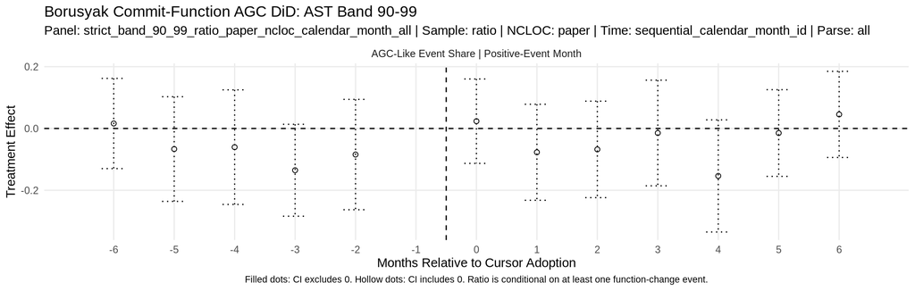

```r
if (nrow(dynamic_df) > 0) {
  dynamic_df$outcome_label <- factor(
    dynamic_df$outcome_label,
    levels = outcome_names
  )

  plot_object <- ggplot(dynamic_df, aes(x = time, y = estimate)) +
    geom_errorbar(
      data = subset(dynamic_df, significant %in% TRUE),
      aes(ymin = conf_low, ymax = conf_high),
      width = 0.4,
      linetype = "solid"
    ) +
    geom_errorbar(
      data = subset(dynamic_df, !(significant %in% TRUE)),
      aes(ymin = conf_low, ymax = conf_high),
      width = 0.4,
      linetype = "dotted"
    ) +
    geom_point(
      data = subset(dynamic_df, significant %in% TRUE),
      shape = 19,
      size = 1.7
    ) +
    geom_point(
      data = subset(dynamic_df, !(significant %in% TRUE)),
      shape = 21,
      fill = "transparent",
      size = 1.7
    ) +
    geom_hline(yintercept = 0, linetype = "dashed") +
    geom_vline(xintercept = -0.5, linetype = "dashed") +
    scale_x_continuous(breaks = -6:6) +
    coord_cartesian(xlim = c(-6.5, 6.5)) +
    facet_wrap(~ outcome_label, scales = "free_y", nrow = 1) +
    labs(
      title = paste("Borusyak Commit-Function AGC DiD: AST Band", ast_sequence_token_band),
      subtitle = paste(
        "Panel:", panel_label,
        "| Sample:", sample_type,
        "| NCLOC:", ncloc_spec,
        "| Time:", time_encoding_used,
        "| Parse:", parse_exclusion_mode
      ),
      x = "Months Relative to Cursor Adoption",
      y = "Treatment Effect",
      caption = paste(
        "Filled dots: CI excludes 0. Hollow dots: CI includes 0.",
        if (sample_type == "ratio") {
          "Ratio is conditional on at least one function-change event."
        } else {
          "Zero-event repository-months are retained."
        }
      )
    ) +
    theme_minimal() +
    theme(
      panel.grid.minor = element_blank(),
      plot.caption = element_text(hjust = 0.5, size = 8)
    )

  print(plot_object)
  ggsave(
    filename = output_file("_dynamic_effects", "pdf"),
    plot = plot_object,
    width = 11,
    height = 3.5
  )
} else {
  cat("No dynamic effects to plot.\n")
}
```

# 11 Final Model Validation (Hard Fail)

`tryCatch()` around the static and dynamic estimators only prevents a single outcome failure from aborting the whole run; it does not guarantee that the run produced usable results. This chunk turns model-fitting failures into a render failure instead of a silently incomplete HTML report with an exit code of 0.

```r
static_model_error_count <- length(static_errors)
dynamic_model_error_count <- length(dynamic_errors)

static_effects_complete <- all(outcome_vars %in% static_df$outcome) &&
  all(!is.na(static_df$estimate[match(outcome_vars, static_df$outcome)]))

dynamic_effects_nonempty <- nrow(dynamic_df) > 0 &&
  all(outcome_vars %in% dynamic_df$outcome)

dynamic_pre_period_present <- if (dynamic_effects_nonempty) {
  all(sapply(outcome_vars, function(v) {
    any(dynamic_df$outcome == v & dynamic_df$time < 0)
  }))
} else {
  FALSE
}

dynamic_post_period_present <- if (dynamic_effects_nonempty) {
  all(sapply(outcome_vars, function(v) {
    any(dynamic_df$outcome == v & dynamic_df$time >= 0)
  }))
} else {
  FALSE
}

final_model_validation <- data.frame(
  check = c(
    "static_model_error_count",
    "dynamic_model_error_count",
    "static_effects_complete",
    "dynamic_effects_nonempty",
    "dynamic_pre_period_present",
    "dynamic_post_period_present"
  ),
  value = c(
    static_model_error_count,
    dynamic_model_error_count,
    static_effects_complete,
    dynamic_effects_nonempty,
    dynamic_pre_period_present,
    dynamic_post_period_present
  ),
  stringsAsFactors = FALSE
)
final_model_validation <- add_run_metadata(
  final_model_validation,
  run_metadata
)

print(final_model_validation)
```

```
##                         check value ast_sequence_token_band
## 1    static_model_error_count     0                   90-99
## 2   dynamic_model_error_count     0                   90-99
## 3     static_effects_complete     1                   90-99
## 4    dynamic_effects_nonempty     1                   90-99
## 5  dynamic_pre_period_present     1                   90-99
## 6 dynamic_post_period_present     1                   90-99
##   ast_sequence_token_lower_bound_inclusive
## 1                                       90
## 2                                       90
## 3                                       90
## 4                                       90
## 5                                       90
## 6                                       90
##   ast_sequence_token_upper_bound_exclusive ast_sequence_token_specification
```

[output cut: 20 more lines]

```r
fwrite(
  final_model_validation,
  output_file("_final_model_validation")
)

if (static_model_error_count > 0) {
  stop(
    "Static model failed for ",
    static_model_error_count,
    " outcome(s): ",
    paste(names(static_errors), collapse = ", ")
  )
}
if (dynamic_model_error_count > 0) {
  stop(
    "Dynamic model failed for ",
    dynamic_model_error_count,
    " outcome(s): ",
    paste(names(dynamic_errors), collapse = ", ")
  )
}
if (!static_effects_complete) {
  stop("Static effects are missing or NA for at least one outcome.")
}
if (!dynamic_effects_nonempty) {
  stop("Dynamic effects are empty for at least one outcome.")
}
if (!dynamic_pre_period_present) {
  stop("Dynamic effects have no pre-treatment horizon for at least one outcome.")
}
if (!dynamic_post_period_present) {
  stop("Dynamic effects have no post-treatment horizon for at least one outcome.")
}

cat("Final model validation: PASS\n")
```

```
## Final model validation: PASS
```

# 12 Metadata

```r
metadata <- data.frame(
  key = c(
    "script",
    "helper_file",
    "panel_label",
    "panel_path",
    "out_dir",
    "ast_sequence_token_band",
    "ast_sequence_token_lower_bound_inclusive",
    "ast_sequence_token_upper_bound_exclusive",
    "ast_sequence_token_specification",
    "sample_type",
    "ncloc_specification",
    "ncloc_column",
    "readiness_column",
    "parse_exclusion_mode",
    "outcomes",
    "activity_reference_outcomes",
    "covariates",
    "first_stage_formula",
    "rows_after_readiness_filter",
    "rows_after_parse_filter",
    "rows_after_ratio_filter",
    "rows_after_cohort_filter",
    "rows_used_by_models",
    "repositories_used_by_models",
    "estimator",
    "time_encoding",
    "event_time_encoding_mismatch_rows",
    "horizon",
    "pretrends",
    "static_model_error_count",
    "dynamic_model_error_count",
    "input_source",
    "interpretation_note",
    "limitation_note"
  ),
  value = c(
    "proc_r/DiffInDiffBorusyak_agc_commit_function_ast_sequence_band.Rmd",
    helper_path,
    panel_label,
    panel_path,
    out_dir,
    ast_sequence_token_band,
    ast_sequence_token_lower,
    ast_sequence_token_upper_exclusive,
    "bounded_band",
    sample_type,
    ncloc_spec,
    ncloc_column,
    readiness_column,
    parse_exclusion_mode,
    paste(outcome_vars, collapse = ", "),
    "log1p_commits, log1p_lines_added (common reference outcomes; not re-estimated by band)",
    paste(covariates, collapse = " + "),
    paste(deparse(first_stage_formula), collapse = " "),
    rows_after_readiness_filter,
    rows_after_parse_filter,
    rows_after_ratio_filter,
    rows_after_cohort_filter,
    nrow(panel_data),
    uniqueN(panel_data$repo_id),
    "Borusyak imputation via didimputation::did_imputation",
    time_encoding_used,
    event_time_encoding_mismatch_rows,
    "-6:6",
    "-6:-2",
    static_model_error_count,
    dynamic_model_error_count,
    paste(
      "run-py-6a bounded AST sequence token band panel derived from",
      "event-level commit-function AGC detector predictions and the",
      "run-py-5e covariate-complete repository-month panel"
    ),
    if (sample_type == "ratio") {
      paste(
        "Conditional composition effect among repository-months with at",
        "least one function-change event in this AST sequence token band;",
        "not an unconditional total effect."
      )
    } else {
      paste(
        "Occurrence and count outcomes use the full zero-inclusive",
        "repository-month panel for this AST sequence token band."
      )
    },
    paste(
      "The outcome captures AST-based structural patterns classified as",
      "AI-likely-generated code; it does not establish function provenance",
      "or identify which AI tool, if any, contributed to a function."
    )
  ),
  stringsAsFactors = FALSE
)

print(metadata)
```

```
##                                         key
## 1                                    script
## 2                               helper_file
## 3                               panel_label
## 4                                panel_path
## 5                                   out_dir
## 6                   ast_sequence_token_band
## 7  ast_sequence_token_lower_bound_inclusive
## 8  ast_sequence_token_upper_bound_exclusive
## 9          ast_sequence_token_specification
## 10                              sample_type
## 11                      ncloc_specification
## 12                             ncloc_column
## 13                         readiness_column
## 14                     parse_exclusion_mode
```

[output cut: 55 more lines]

```r
fwrite(metadata, output_file("_metadata"))
```